# ODA

Oscar Morales

2024-09-11

# Manual para Replicar

## Cargar Librerias

```r
library(tidyverse) # manejo de dataframes
library(reshape2)  # para tranfromar data de long a wide
library(WDI)       # libreria para acceder a metadata de banco mundial
library(readxl)    # leer archivos de excel
library(readr)     # leer archivos csv
library(visdat)    # visualizacion de datos como graficos
library(plotly)    # graficos
library(plm)       # modelos lineales para datos panel
library(lmtest)    # Pruebas de modelos lineales
library(broom)     # Manejar tablas
library(knitr)     # Imprimir tablas
library(car)       # test y utilidades para modelos
```

## Cargar Datos

### Paises

```r
country_class <- read_excel("Data/CLASS.xlsx", sheet = "List of economies")
country_class <- country_class %>%
  filter(!is.na(Region), !is.na(`Income group`)) %>%
  merge(WDI_data$country, by.x='Code', by.y ='iso3c') %>%
  select(Code, iso2c, country, Region, `Income group`) %>%
  rename(iso3c = `Code`, region = Region, income = `Income group`)
```

### V-DEM

```r
v_dem_vars <- c("Electoral democracy index", "Exclusion by Gender index")
V_DEM <- read_excel("Data/VDEM-CORE.xlsx", sheet = "Data")

V_DEM <- V_DEM %>%
  select(-3, -5, -6, -7, -8) %>%
  filter(Indicator %in% v_dem_vars) %>%
  rename(iso3c = `Economy ISO3`, country = `Economy Name`, indicator = Indicator) %>%
  melt(id.vars = c("iso3c", "country", "indicator"), variable.name = "year") %>%
  arrange(iso3c, indicator, year) %>%
  merge(country_class) %>%
  select(iso2c, indicator, year, value)

V_DEM$indicator[V_DEM$indicator == "Electoral democracy index"] <- "dem"
V_DEM$indicator[V_DEM$indicator == "Exclusion by Gender index"] <- "exc"
v_dem_vars <- c("dem", "exc")
```

### HDI

```r
hdi_vars <- c('hdi')
HDI <- read_csv("Data/datos_python_HDI.csv",
                col_names = c('Code', 'iso2c', 'indicator', 'year', 'value'),
                col_types = list(col_character(),
                                 col_character(),
                                 col_character(),
                                 col_double(),
                                 col_double()),
                na = 'None') %>%
  filter(indicator %in% hdi_vars) %>%
  select(iso2c, indicator, year, value)
```

### WORLD BANK

```r
wb_vars <- c('ODA.GNI','ODA.ALL','ODA.PC','CC','GE','PV','RQ','RL','VA','GDP.PC','GDP.PPP','GROW','SAV')
WB <- data.frame(indicator = character(), iso2c = character(), year = double(), value = double())


for (indicator in wb_vars) {
  WB <- rbind(WB, read_csv(paste("Data/datos_python_", indicator, ".csv", sep =''),
                           col_names = c('indicator', 'iso2c', 'year', 'value'),
                           col_types = list(col_character(), col_character(), col_double(), col_double()),
                           na = "None"))
}

WB <- WB %>% select(iso2c, indicator, year, value)
```

### CLIO-INFRA

```r
CLIO <- read_excel("Data/GlobalExtremePovertyDollaraDay_Compact.xlsx", sheet = "Data Long Format")

names(CLIO) <- c("ccode", "country", "year", "value")

CLIO[CLIO=="Cape Verde"] <- "Cabo Verde"
CLIO[CLIO=="Congo"] <- "Congo, Rep."
CLIO[CLIO=="Egypt"] <- "Egypt, Arab Rep."
CLIO[CLIO=="Iran"] <- "Iran, Islamic Rep."
CLIO[CLIO=="Kyrgyzstan"] <- "Kyrgyz Republic"
CLIO[CLIO=="Laos"] <- "Lao PDR"
CLIO[CLIO=="Macedonia"] <- "North Macedonia"
CLIO[CLIO=="Russia"] <- "Russian Federation"
CLIO[CLIO=="Slovakia"] <- "Slovak Republic"
CLIO[CLIO=="South Korea"] <- "Korea, Rep."
CLIO[CLIO=="Swaziland"] <- "Eswatini"
CLIO[CLIO=="Syria"] <- "Syrian Arab Republic"
CLIO[CLIO=="The Gambia"] <- "Gambia, The"
CLIO[CLIO=="Turkey"] <- "Turkiye"
CLIO[CLIO=="Venezuela"] <- "Venezuela, RB"
CLIO[CLIO=="Yemen"] <- "Yemen, Rep."

CLIO <- CLIO %>%
  merge(WDI_data$country, all.x = TRUE) %>%
  mutate(indicator = 'POV') %>%
  select(indicator, iso2c, year, value) %>%
  arrange(iso2c, year) %>%
  select(iso2c, indicator, year, value)
```

### OUR WORLD IN DATA

```r
LIBERTIES <- read_csv("DATA/political-civil-liberties-index.csv") %>%
  filter(!is.na(Code)) %>%
  mutate(indicator = 'LIB') %>%
  merge(country_class, by.x = 'Code', by.y = 'iso3c') %>%
  select(iso2c, indicator, year, value)
```

## Manipular Datos

### Transformar datos a la estructura wide

```r
datos_paper <- rbind(WB, HDI, CLIO, LIBERTIES, V_DEM) %>%
  pivot_wider(names_from = indicator, values_from = value) %>%
  complete(iso2c, year)
```

### Definir Indice de Governanza

```r
datos_paper <- datos_paper %>% mutate(GOV = (CC + GE + PV + RQ + RL + VA) / 6)
```

### Definir variables Dicotomicas / clasificacion

```r
datos_paper <- datos_paper %>% mutate(GOV_high = case_when(is.na(GOV) ~ NA_real_, GOV >= 0 ~ 1, TRUE ~ 0))

dem_avg <- read_csv("Data/Electoral Democracy Index.csv", show_col_types = FALSE)

datos_paper <- datos_paper %>% merge(dem_avg %>% select(1, 2), by.x = 'year', by.y = 'Year', all.x = TRUE) %>%
                mutate(dem_high = case_when(is.na(dem) ~ NA_real_,
                                            is.na(`*World`) ~ NA_real_,
                                            dem >= `*World` ~ 1,
                                            TRUE ~ 0)) %>% select(-`*World`)

exc_avg <- read_csv("Data/Exclusion by Gender.csv", show_col_types = FALSE)

datos_paper <- datos_paper %>% merge(exc_avg %>% select(1, 2), by.x = 'year', by.y = 'Year', all.x = TRUE) %>%
                mutate(exc_high = case_when(is.na(exc) ~ NA_real_,
                                            is.na(`*World`) ~ NA_real_,
                                            exc >= `*World` ~ 1,
                                            TRUE ~ 0)) %>% select(-`*World`) %>%
                mutate(no_exc = 1 - exc, no_exc_high = 1 - exc_high, inv_exc = 1 / exc, inv_exc_high = 1 - exc_high)


lib_avg <- read_csv("DATA/political-civil-liberties-index.csv", show_col_types = FALSE) %>% filter(Code == 'OWID_WRL')

datos_paper <- datos_paper %>% merge(lib_avg %>% select(3, 4) %>% rename(WORLD = value), all.x = TRUE) %>%
                mutate(lib_high = case_when(is.na(LIB) ~ NA_real_,
                                            is.na(WORLD) ~ NA_real_,
                                            LIB >= WORLD ~ 1,
                                            TRUE ~ 0)) %>% select(-WORLD)

datos_paper <- datos_paper %>% merge(country_class %>% select(iso2c, region, income), all.x = TRUE)
```

### Filtros

```
## # A tibble: 3 × 2
##   income              countries
##   <chr>                   <int>
## 1 Low income                 12
## 2 Lower middle income        35
## 3 Upper middle income        30
```

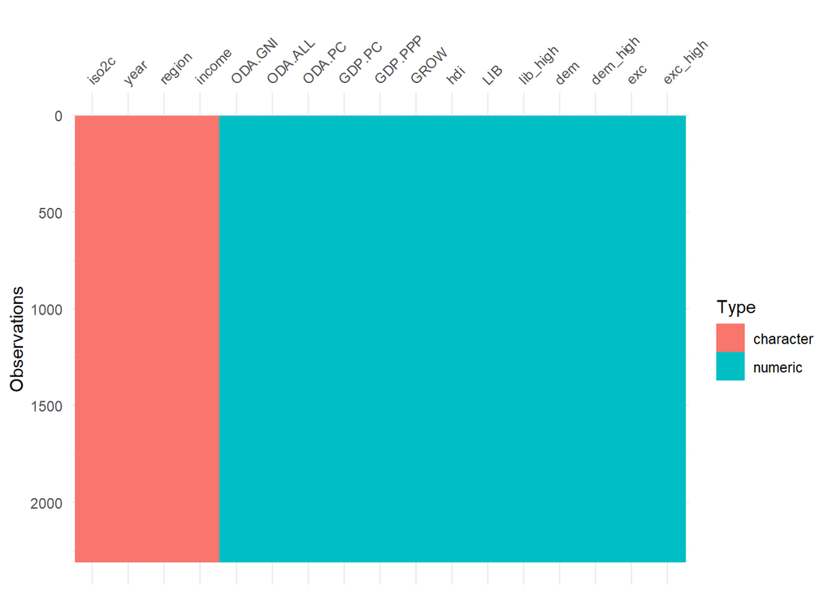

```
## #### Filtro de países
```

```
##  [1] "AF" "AO" "AZ" "BA" "BF" "BT" "BY" "BZ" "CU" "CV" "DJ" "DM" "ER" "ET" "FM"
## [16] "GD" "GE" "GN" "GQ" "GW" "KI" "KM" "KP" "LB" "LC" "LR" "LY" "MD" "ME" "MG"
## [31] "MH" "MK" "MV" "NG" "PS" "RS" "RW" "SB" "SO" "SR" "SS" "SY" "TD" "TL" "TM"
## [46] "TO" "TV" "UA" "UZ" "VC" "VU" "WS" "XK" "YE"
```

```
## #### Primer año
```

```
## [1] 1993
```

```
## #### Ultimo año
```

```
## [1] 2022
```

## Modelos

```r
# 1993 - 2022
datos_model <- country_class %>% filter(income != 'High income') %>% merge(datos_paper) %>%
  select(iso2c, year, region, income, ODA.GNI, ODA.ALL, ODA.PC, GDP.PC, GDP.PPP,
         GROW, hdi, LIB, lib_high, dem, dem_high, exc, exc_high, no_exc, no_exc_high, inv_exc, inv_exc_high) %>%
  arrange(iso2c, year) %>% filter(year >= first_y, year <= last_y, !iso2c %in% filtro_c)
```

```r
# 2002 - 2022
# datos_model <- country_class %>% filter(!income %in% c('High income', 'Upper middle income')) %>% merge(datos_paper) %>%
#   select(iso2c, year, ODA.ALL, ODA.PC, GDP.PC, GROW, hdi, GOV, GOV_high) %>%
#   arrange(iso2c, year) %>% filter(year >= 2002, year <= last_y,
#                                   !iso2c %in% c('SS', 'BT', 'ER', 'GW', 'KP', 'LB', 'NG', 'PS', 'SO', 'VU', 'FM', 'KI', 'SB', 'SY'))
```

```r
formulas <- list(
  # list(name = 'modelo1', vd = 'hdi', vi = c('ODA.GNI','GDP.PPP','GROW','LIB','dem','exc'), vint = c()),
  # list(name = 'modelo2', vd = 'hdi', vi = c('ODA.GNI','GDP.PC' ,'GROW','LIB','dem','exc'), vint = c()),
  # list(name = 'modelo3', vd = 'hdi', vi = c('ODA.GNI','GDP.PC' ,'GROW','LIB','dem'),       vint = c()),
  # list(name = 'modelo4', vd = 'hdi', vi = c('GDP.PC' ,'GROW', 'dem', 'LIB'), vint = c('ODA.GNI*dem_high')),
  # list(name = 'modelo5', vd = 'hdi', vi = c('GDP.PC' ,'GROW', 'dem'), vint = c('ODA.GNI*dem_high')),
  # list(name = 'modelo6', vd = 'hdi', vi = c('GDP.PC' ,'GROW', 'exc'), vint = c('ODA.GNI*exc_high')),
  # list(name = 'Original', vd = 'hdi', vi = c('GDP.PC' ,'GOV'), vint = c('ODA.PC*GOV_high')),
  # list(name = 'modelo7', vd = 'hdi', vi = c('GDP.PC' ,'GROW', 'dem'), vint = c('ODA.PC*dem_high')),
  # list(name = 'modelo8', vd = 'hdi', vi = c('GDP.PC' ,'GROW', 'exc'), vint = c('ODA.PC*exc_high')),
  # list(name = 'modelo9', vd = 'hdi', vi = c('GDP.PC' ,'GROW', 'LIB'), vint = c('ODA.PC*lib_high')),
  # list(name = 'modelo10', vd = 'GDP.PC', vi = c('ODA.PC', 'hdi' ,'GROW', 'LIB', 'dem', 'exc'), vint = c()),
  # list(name = 'modelo11', vd = 'GDP.PC', vi = c('ODA.PC', 'hdi' ,'GROW', 'dem', 'exc'), vint = c()),
  # list(name = 'modelo12', vd = 'GDP.PC', vi = c('hdi' ,'GROW', 'dem'), vint = c('ODA.PC*dem_high')),
  # list(name = 'modelo13', vd = 'GDP.PC', vi = c('hdi' ,'GROW', 'exc'), vint = c('ODA.PC*exc_high')),
  # list(name = 'gdp modelo14', vd = 'GDP.PC', vi = c('ODA.PC' ,'hdi','GROW', 'dem'), vint = c(),
  #      vf = c('factor(region)', 'factor(income)')),
  # list(name = 'gdp modelo15', vd = 'GDP.PC', vi = c('ODA.PC' ,'hdi','GROW', 'exc'), vint = c(),
  #      vf = c('factor(region)', 'factor(income)')),
  # list(name = 'gdp modelo16', vd = 'GDP.PC', vi = c('ODA.PC' ,'GROW', 'dem'), vint = c(),
  # vf = c('factor(region)', 'factor(income)')),
  # list(name = 'gdp modelo17', vd = 'GDP.PC', vi = c('ODA.PC' ,'GROW', 'exc'), vint = c(),
  #      vf = c('factor(region)', 'factor(income)')),
  # list(name = 'gdp modelo17 no', vd = 'GDP.PC', vi = c('ODA.PC' ,'GROW', 'no_exc'), vint = c(),
  #      vf = c('factor(region)', 'factor(income)')),
  list(name = 'gdp modelo17 inv', vd = 'GDP.PC', vi = c('ODA.PC' ,'GROW', 'inv_exc'), vint = c(),
       vf = c('factor(region)', 'factor(income)')),
  # list(name = 'gdp modelo18', vd = 'GDP.PC', vi = c('ODA.PC' ,'GROW', 'LIB'), vint = c(), vf = c('factor(region)', 'factor(income)')),
  #list(name = 'hdi modelo14', vd = 'hdi', vi = c('ODA.PC', 'GDP.PC', 'dem'), vint = c(), vf = c('factor(region)', 'factor(income)')),
  #list(name = 'hdi modelo15', vd = 'hdi', vi = c('ODA.PC', 'GDP.PC', 'exc'), vint = c(), vf = c()),
  # list(name = 'hdi modelo19', vd = 'hdi', vi = c('ODA.PC', 'GDP.PC', 'LIB'), vint = c(), vf = c()),
  list(name = 'hdi modelo20', vd = 'hdi', vi = c('GDP.PC', 'exc'), vint = c('ODA.PC*exc_high'), vf = c()),
  #list(name = 'hdi modelo21', vd = 'hdi', vi = c('GDP.PC', 'dem'), vint = c('ODA.PC*dem_high'), vf = c()),
  #list(name = 'hdi modelo22', vd = 'hdi', vi = c('GDP.PC', 'exc'), vint = c('ODA.PC*exc_high'), vf = c('factor(region)', 'factor(income)'))
  list(name = 'gdp modelo23', vd = 'GDP.PC', vi = c('GROW', 'exc'), vint = c('ODA.PC*exc_high'), vf = c()),
  # list(name = 'hdi modelo24 inv', vd = 'hdi', vi = c('GDP.PC', 'inv_exc'), vint = c('ODA.PC*inv_exc_high'), vf = c()),
  # list(name = 'gdp modelo25 inv', vd = 'GDP.PC', vi = c('GROW', 'inv_exc'), vint = c('ODA.PC*inv_exc_high'), vf = c())
  list(name = 'gdp modelo26', vd = 'GDP.PC', vi = c('hdi', 'exc'), vint = c('ODA.PC*exc_high'), vf = c())
  )
```

### gdp modelo17 inv

#### GDP.PC ~ ODA.PC + GROW + inv_exc + factor(region) + factor(income)

##### OLS

| term | estimate | std.error | statistic | p.value | significant |
| --- | --- | --- | --- | --- | --- |
| (Intercept) | -315.4800027 | 199.6569833 | -1.5801100 | 0.1142192 |  |
| ODA.PC | -0.7309554 | 0.7872624 | -0.9284775 | 0.3532574 |  |
| GROW | -13.0540863 | 46.9445633 | -0.2780745 | 0.7809802 |  |
| inv_exc | 218.2577641 | 16.5343520 | 13.2002612 | 0.0000000 | *** |
| factor(region)Europe & Central Asia | 278.3852161 | 179.4749356 | 1.5511092 | 0.1210132 |  |
| factor(region)Latin America & Caribbean | 500.2737889 | 138.6245625 | 3.6088394 | 0.0003141 | *** |
| factor(region)Middle East & North Africa | 725.1796755 | 169.3029187 | 4.2833265 | 0.0000192 | *** |
| factor(region)South Asia | 30.2532919 | 195.2779089 | 0.1549243 | 0.8768946 |  |
| factor(region)Sub-Saharan Africa | 375.2344713 | 136.9055522 | 2.7408273 | 0.0061759 | ** |
| factor(income)Lower middle income | 905.5921592 | 135.1356237 | 6.7013578 | 0.0000000 | *** |
| factor(income)Upper middle income | 3984.5196013 | 157.7647841 | 25.2560774 | 0.0000000 | *** |

- R-Squared: 0.5030472
- Breusch-Pagan LM test - Cross Sectional Dependance

| statistic | p.value | parameter | method | alternative |
| --- | --- | --- | --- | --- |
| 59571.49 | 0 | 2926 | Breusch-Pagan LM test for cross-sectional dependence in panels | cross-sectional dependence |

- Pesaran CD test - Cross Sectional Dependance

| statistic | p.value | method | alternative |
| --- | --- | --- | --- |
| 226.9916 | 0 | Pesaran CD test for cross-sectional dependence in panels | cross-sectional dependence |

- Serial Correlation

| statistic | p.value | parameter | method | alternative |
| --- | --- | --- | --- | --- |
| 1959.758 | 0 | 30 | Breusch-Godfrey/Wooldridge test for serial correlation in panel models | serial correlation in idiosyncratic errors |

- Robust covariance matrix estimation

| term | estimate | std.error | statistic | p.value | significant |
| --- | --- | --- | --- | --- | --- |
| (Intercept) | -315.4800027 | 183.2639519 | -1.7214515 | 0.0853035 | . |
| ODA.PC | -0.7309554 | 0.6547033 | -1.1164682 | 0.2643384 |  |
| GROW | -13.0540863 | 50.6810807 | -0.2575732 | 0.7967594 |  |
| inv_exc | 218.2577641 | 25.3644405 | 8.6048720 | 0.0000000 | *** |
| factor(region)Europe & Central Asia | 278.3852161 | 264.7076773 | 1.0516704 | 0.2930613 |  |
| factor(region)Latin America & Caribbean | 500.2737889 | 162.0563821 | 3.0870354 | 0.0020458 | ** |
| factor(region)Middle East & North Africa | 725.1796755 | 167.5261332 | 4.3287555 | 0.0000156 | *** |
| factor(region)South Asia | 30.2532919 | 132.0744497 | 0.2290624 | 0.8188408 |  |
| factor(region)Sub-Saharan Africa | 375.2344713 | 131.2139300 | 2.8597152 | 0.0042785 | ** |
| factor(income)Lower middle income | 905.5921592 | 64.1206633 | 14.1232500 | 0.0000000 | *** |
| factor(income)Upper middle income | 3984.5196013 | 130.4304310 | 30.5490028 | 0.0000000 | *** |

##### Fixed Effects

| term | estimate | std.error | statistic | p.value | significant |
| --- | --- | --- | --- | --- | --- |
| ODA.PC | 4.291608 | 0.8500115 | 5.048882 | 0.0000005 | *** |
| GROW | -199.810077 | 51.6458416 | -3.868851 | 0.0001125 | *** |
| inv_exc | 768.827192 | 40.6763032 | 18.901108 | 0.0000000 | *** |

- R-Squared: 0.1647351
- Breusch-Pagan LM test - Cross Sectional Dependance

| statistic | p.value | parameter | method | alternative |
| --- | --- | --- | --- | --- |
| 37317.57 | 0 | 2926 | Breusch-Pagan LM test for cross-sectional dependence in panels | cross-sectional dependence |

- Pesaran CD test - Cross Sectional Dependance

| statistic | p.value | method | alternative |
| --- | --- | --- | --- |
| 119.6373 | 0 | Pesaran CD test for cross-sectional dependence in panels | cross-sectional dependence |

- Serial Correlation

| statistic | p.value | parameter | method | alternative |
| --- | --- | --- | --- | --- |
| 1784.106 | 0 | 30 | Breusch-Godfrey/Wooldridge test for serial correlation in panel models | serial correlation in idiosyncratic errors |

- Robust covariance matrix estimation

| term | estimate | std.error | statistic | p.value | significant |
| --- | --- | --- | --- | --- | --- |
| ODA.PC | 4.291608 | 1.733989 | 2.4749918 | 0.0133978 | * |
| GROW | -199.810077 | 221.876819 | -0.9005451 | 0.3679275 |  |
| inv_exc | 768.827192 | 129.216242 | 5.9499269 | 0.0000000 | *** |

##### Random Effects

| term | estimate | std.error | statistic | p.value | significant |
| --- | --- | --- | --- | --- | --- |
| (Intercept) | -589.995290 | 612.9152272 | -0.9626050 | 0.3357458 |  |
| ODA.PC | 4.211259 | 0.8432439 | 4.9941177 | 0.0000006 | *** |
| GROW | -194.010864 | 51.2076456 | -3.7887089 | 0.0001514 | *** |
| inv_exc | 583.076833 | 34.4396592 | 16.9303892 | 0.0000000 | *** |
| factor(region)Europe & Central Asia | 114.828955 | 637.0437868 | 0.1802528 | 0.8569541 |  |
| factor(region)Latin America & Caribbean | -28.326399 | 494.3916755 | -0.0572955 | 0.9543098 |  |
| factor(region)Middle East & North Africa | 909.300777 | 603.6796187 | 1.5062638 | 0.1319995 |  |
| factor(region)South Asia | -32.150295 | 697.8750115 | -0.0460688 | 0.9632554 |  |
| factor(region)Sub-Saharan Africa | 79.858812 | 476.6879599 | 0.1675285 | 0.8669542 |  |
| factor(income)Lower middle income | 474.098690 | 477.4868552 | 0.9929042 | 0.3207567 |  |
| factor(income)Upper middle income | 3123.038583 | 540.7342895 | 5.7755512 | 0.0000000 | *** |

- R-Squared: 0.1848251
- Breusch-Pagan LM test - Cross Sectional Dependance

| statistic | p.value | parameter | method | alternative |
| --- | --- | --- | --- | --- |
| 41057.9 | 0 | 2926 | Breusch-Pagan LM test for cross-sectional dependence in panels | cross-sectional dependence |

- Pesaran CD test - Cross Sectional Dependance

| statistic | p.value | method | alternative |
| --- | --- | --- | --- |
| 141.5682 | 0 | Pesaran CD test for cross-sectional dependence in panels | cross-sectional dependence |

- Serial Correlation

| statistic | p.value | parameter | method | alternative |
| --- | --- | --- | --- | --- |
| 1833.038 | 0 | 30 | Breusch-Godfrey/Wooldridge test for serial correlation in panel models | serial correlation in idiosyncratic errors |

- Robust covariance matrix estimation

| term | estimate | std.error | statistic | p.value | significant |
| --- | --- | --- | --- | --- | --- |
| (Intercept) | -589.995290 | 516.481143 | -1.1423366 | 0.2534331 |  |
| ODA.PC | 4.211259 | 1.210324 | 3.4794493 | 0.0005118 | *** |
| GROW | -194.010864 | 64.314470 | -3.0165974 | 0.0025843 | ** |
| inv_exc | 583.076833 | 54.858543 | 10.6287335 | 0.0000000 | *** |
| factor(region)Europe & Central Asia | 114.828955 | 989.058380 | 0.1160993 | 0.9075840 |  |
| factor(region)Latin America & Caribbean | -28.326399 | 582.124101 | -0.0486604 | 0.9611942 |  |
| factor(region)Middle East & North Africa | 909.300777 | 623.002876 | 1.4595451 | 0.1445518 |  |
| factor(region)South Asia | -32.150295 | 478.197896 | -0.0672322 | 0.9464027 |  |
| factor(region)Sub-Saharan Africa | 79.858812 | 459.735345 | 0.1737061 | 0.8621118 |  |
| factor(income)Lower middle income | 474.098690 | 209.133626 | 2.2669654 | 0.0234849 | * |
| factor(income)Upper middle income | 3123.038583 | 428.689589 | 7.2850815 | 0.0000000 | *** |

##### Time-Fixed Effects

| term | estimate | std.error | statistic | p.value | significant |
| --- | --- | --- | --- | --- | --- |
| factor(year)1994 | 37.926854 | 175.708933 | 0.2158505 | 0.8291243 |  |
| factor(year)1995 | 149.405376 | 175.760608 | 0.8500504 | 0.3953895 |  |
| factor(year)1996 | 206.914162 | 175.777390 | 1.1771375 | 0.2392679 |  |
| factor(year)1997 | 205.458935 | 175.944663 | 1.1677475 | 0.2430351 |  |
| factor(year)1998 | 142.123299 | 176.016345 | 0.8074438 | 0.4194981 |  |
| factor(year)1999 | 122.428915 | 176.032800 | 0.6954892 | 0.4868222 |  |
| factor(year)2000 | 93.848282 | 176.474593 | 0.5317949 | 0.5949218 |  |
| factor(year)2001 | 54.418190 | 176.432016 | 0.3084372 | 0.7577789 |  |
| factor(year)2002 | -1.685281 | 176.731675 | -0.0095358 | 0.9923925 |  |
| factor(year)2003 | 154.247076 | 176.801124 | 0.8724327 | 0.3830675 |  |
| factor(year)2004 | 396.163100 | 176.812682 | 2.2405808 | 0.0251526 | * |
| factor(year)2005 | 648.218886 | 177.036810 | 3.6614921 | 0.0002567 | *** |
| factor(year)2006 | 871.639723 | 176.941753 | 4.9261393 | 0.0000009 | *** |
| factor(year)2007 | 1215.759884 | 177.122482 | 6.8639501 | 0.0000000 | *** |
| factor(year)2008 | 1613.857874 | 177.437767 | 9.0953460 | 0.0000000 | *** |
| factor(year)2009 | 1388.948101 | 177.302175 | 7.8337906 | 0.0000000 | *** |
| factor(year)2010 | 1826.167039 | 178.175331 | 10.2492698 | 0.0000000 | *** |
| factor(year)2011 | 2293.036028 | 178.287205 | 12.8614728 | 0.0000000 | *** |
| factor(year)2012 | 2382.757087 | 178.271518 | 13.3658877 | 0.0000000 | *** |
| factor(year)2013 | 2496.490754 | 178.046772 | 14.0215446 | 0.0000000 | *** |
| factor(year)2014 | 2517.463061 | 177.874730 | 14.1530113 | 0.0000000 | *** |
| factor(year)2015 | 2176.082331 | 178.018277 | 12.2239265 | 0.0000000 | *** |
| factor(year)2016 | 2142.013239 | 177.740893 | 12.0513249 | 0.0000000 | *** |
| factor(year)2017 | 2372.856553 | 178.053949 | 13.3266157 | 0.0000000 | *** |
| factor(year)2018 | 2487.398662 | 178.084159 | 13.9675459 | 0.0000000 | *** |
| factor(year)2019 | 2442.732965 | 178.177237 | 13.7095681 | 0.0000000 | *** |
| factor(year)2020 | 2105.128989 | 179.240059 | 11.7447462 | 0.0000000 | *** |
| factor(year)2021 | 2525.933695 | 179.713821 | 14.0553113 | 0.0000000 | *** |
| factor(year)2022 | 2811.140013 | 180.119943 | 15.6070448 | 0.0000000 | *** |
| ODA.PC | -1.417887 | 0.664853 | -2.1326325 | 0.0330653 | * |
| GROW | -44.485816 | 39.459301 | -1.1273848 | 0.2597027 |  |
| inv_exc | 306.258167 | 33.228621 | 9.2166981 | 0.0000000 | *** |

- R-Squared: 0.5323651
- Breusch-Pagan LM test - Cross Sectional Dependance

| statistic | p.value | parameter | method | alternative |
| --- | --- | --- | --- | --- |
| 42640.75 | 0 | 2926 | Breusch-Pagan LM test for cross-sectional dependence in panels | cross-sectional dependence |

- Pesaran CD test - Cross Sectional Dependance

| statistic | p.value | method | alternative |
| --- | --- | --- | --- |
| 12.7037 | 0 | Pesaran CD test for cross-sectional dependence in panels | cross-sectional dependence |

- Serial Correlation

| statistic | p.value | parameter | method | alternative |
| --- | --- | --- | --- | --- |
| 1806.324 | 0 | 30 | Breusch-Godfrey/Wooldridge test for serial correlation in panel models | serial correlation in idiosyncratic errors |

- Robust covariance matrix estimation

| term | estimate | std.error | statistic | p.value | significant |
| --- | --- | --- | --- | --- | --- |
| factor(year)1994 | 37.926854 | 25.990070 | 1.4592825 | 0.1446301 |  |
| factor(year)1995 | 149.405376 | 48.965690 | 3.0512258 | 0.0023063 | ** |
| factor(year)1996 | 206.914162 | 55.714310 | 3.7138423 | 0.0002092 | *** |
| factor(year)1997 | 205.458935 | 57.298630 | 3.5857565 | 0.0003434 | *** |
| factor(year)1998 | 142.123299 | 62.747530 | 2.2650023 | 0.0236094 | * |
| factor(year)1999 | 122.428915 | 55.993976 | 2.1864658 | 0.0288865 | * |
| factor(year)2000 | 93.848282 | 83.879997 | 1.1188398 | 0.2633306 |  |
| factor(year)2001 | 54.418190 | 82.471019 | 0.6598462 | 0.5094216 |  |
| factor(year)2002 | -1.685281 | 115.634612 | -0.0145742 | 0.9883732 |  |
| factor(year)2003 | 154.247076 | 118.390888 | 1.3028627 | 0.1927579 |  |
| factor(year)2004 | 396.163100 | 131.599150 | 3.0103773 | 0.0026389 | ** |
| factor(year)2005 | 648.218886 | 154.307532 | 4.2008247 | 0.0000277 | *** |
| factor(year)2006 | 871.639723 | 166.669752 | 5.2297415 | 0.0000002 | *** |
| factor(year)2007 | 1215.759884 | 202.153643 | 6.0140390 | 0.0000000 | *** |
| factor(year)2008 | 1613.857874 | 242.046015 | 6.6675664 | 0.0000000 | *** |
| factor(year)2009 | 1388.948101 | 200.653234 | 6.9221316 | 0.0000000 | *** |
| factor(year)2010 | 1826.167039 | 254.639822 | 7.1715689 | 0.0000000 | *** |
| factor(year)2011 | 2293.036028 | 307.928077 | 7.4466611 | 0.0000000 | *** |
| factor(year)2012 | 2382.757087 | 316.659839 | 7.5246583 | 0.0000000 | *** |
| factor(year)2013 | 2496.490754 | 322.082647 | 7.7510874 | 0.0000000 | *** |
| factor(year)2014 | 2517.463061 | 306.112019 | 8.2239929 | 0.0000000 | *** |
| factor(year)2015 | 2176.082331 | 269.751032 | 8.0670028 | 0.0000000 | *** |
| factor(year)2016 | 2142.013239 | 252.060374 | 8.4980166 | 0.0000000 | *** |
| factor(year)2017 | 2372.856553 | 283.909154 | 8.3578022 | 0.0000000 | *** |
| factor(year)2018 | 2487.398662 | 285.816092 | 8.7027943 | 0.0000000 | *** |
| factor(year)2019 | 2442.732965 | 285.511881 | 8.5556263 | 0.0000000 | *** |
| factor(year)2020 | 2105.128989 | 270.015306 | 7.7963321 | 0.0000000 | *** |
| factor(year)2021 | 2525.933695 | 313.586430 | 8.0549841 | 0.0000000 | *** |
| factor(year)2022 | 2811.140013 | 360.422481 | 7.7995690 | 0.0000000 | *** |
| ODA.PC | -1.417887 | 1.035158 | -1.3697298 | 0.1709110 |  |
| GROW | -44.485816 | 167.173937 | -0.2661050 | 0.7901833 |  |
| inv_exc | 306.258167 | 100.462854 | 3.0484717 | 0.0023275 | ** |

##### Tests

- Breusch Pagan Test (heteroskedasticity)

| statistic | p.value | parameter | method | alternative |
| --- | --- | --- | --- | --- |
| 1387.611 | 0 | 10 | Breusch-Pagan test | heteroskedasticity |

- Variance Inflation Factors - multicollinearity

|  | GVIF | Df | GVIF^(1/(2*Df)) |
| --- | --- | --- | --- |
| ODA.PC | 1.131580 | 1 | 1.063758 |
| GROW | 1.584721 | 1 | 1.258857 |
| inv_exc | 1.176578 | 1 | 1.084702 |
| factor(region) | 2.366708 | 5 | 1.089970 |
| factor(income) | 2.116343 | 2 | 1.206137 |

- Test for Fixed Effects

```
## Multiple parameters; naming those columns df1, df2
```

| df1 | df2 | statistic | p.value | method | alternative |
| --- | --- | --- | --- | --- | --- |
| 69 | 2230 | 26.36724 | 0 | F test for individual effects | significant effects |

- Hausman Test

| statistic | p.value | parameter | method | alternative |
| --- | --- | --- | --- | --- |
| 121.2598 | 0 | 3 | Hausman Test | one model is inconsistent |

- Test for Time-Fixed Effects

```
## Multiple parameters; naming those columns df1, df2
```

| df1 | df2 | statistic | p.value | method | alternative |
| --- | --- | --- | --- | --- | --- |
| 29 | 2201 | 59.66588 | 0 | F test for individual effects | significant effects |

##### Unit Root Test

- GDP.PC

| statistic | p.value | parameter | method | alternative |
| --- | --- | --- | --- | --- |
| 53.23557 | 1 | 154 | Maddala-Wu Unit-Root Test (ex. var.: Individual Intercepts) | stationarity |

- ODA.PC

| statistic | p.value | parameter | method | alternative |
| --- | --- | --- | --- | --- |
| 456.0406 | 0 | 154 | Maddala-Wu Unit-Root Test (ex. var.: Individual Intercepts) | stationarity |

- GROW

| statistic | p.value | parameter | method | alternative |
| --- | --- | --- | --- | --- |
| 544.7777 | 0 | 154 | Maddala-Wu Unit-Root Test (ex. var.: Individual Intercepts) | stationarity |

- inv_exc

| statistic | p.value | parameter | method | alternative |
| --- | --- | --- | --- | --- |
| 285.5842 | 0 | 154 | Maddala-Wu Unit-Root Test (ex. var.: Individual Intercepts) | stationarity |

### hdi modelo20

#### hdi ~ ODA.PC x exc_high + GDP.PC + exc

##### OLS

| term | estimate | std.error | statistic | p.value | significant |
| --- | --- | --- | --- | --- | --- |
| (Intercept) | 0.5045561 | 0.0062327 | 80.9526512 | 0.0000000 | *** |
| ODA.PC | 0.0000658 | 0.0000660 | 0.9979901 | 0.3183890 |  |
| exc_high | -0.0273137 | 0.0069231 | -3.9452946 | 0.0000821 | *** |
| GDP.PC | 0.0000354 | 0.0000007 | 51.0469154 | 0.0000000 | *** |
| exc | 0.0083885 | 0.0146764 | 0.5715656 | 0.5676721 |  |
| ODA.PC:exc_high | -0.0000928 | 0.0000762 | -1.2179073 | 0.2233839 |  |

- R-Squared: 0.5706135
- Breusch-Pagan LM test - Cross Sectional Dependance

| statistic | p.value | parameter | method | alternative |
| --- | --- | --- | --- | --- |
| 33650.77 | 0 | 2926 | Breusch-Pagan LM test for cross-sectional dependence in panels | cross-sectional dependence |

- Pesaran CD test - Cross Sectional Dependance

| statistic | p.value | method | alternative |
| --- | --- | --- | --- |
| 42.32757 | 0 | Pesaran CD test for cross-sectional dependence in panels | cross-sectional dependence |

- Serial Correlation

| statistic | p.value | parameter | method | alternative |
| --- | --- | --- | --- | --- |
| 2084.092 | 0 | 30 | Breusch-Godfrey/Wooldridge test for serial correlation in panel models | serial correlation in idiosyncratic errors |

- Robust covariance matrix estimation

| term | estimate | std.error | statistic | p.value | significant |
| --- | --- | --- | --- | --- | --- |
| (Intercept) | 0.5045561 | 0.0060831 | 82.9445243 | 0.0000000 | *** |
| ODA.PC | 0.0000658 | 0.0000650 | 1.0133527 | 0.3109981 |  |
| exc_high | -0.0273137 | 0.0068056 | -4.0133849 | 0.0000618 | *** |
| GDP.PC | 0.0000354 | 0.0000008 | 45.2753250 | 0.0000000 | *** |
| exc | 0.0083885 | 0.0134999 | 0.6213764 | 0.5344134 |  |
| ODA.PC:exc_high | -0.0000928 | 0.0000704 | -1.3167219 | 0.1880628 |  |

##### Fixed Effects

| term | estimate | std.error | statistic | p.value | significant |
| --- | --- | --- | --- | --- | --- |
| ODA.PC | 0.0001893 | 0.0000377 | 5.026430 | 0.0000005 | *** |
| exc_high | 0.0155413 | 0.0044658 | 3.480048 | 0.0005110 | *** |
| GDP.PC | 0.0000165 | 0.0000005 | 32.975269 | 0.0000000 | *** |
| exc | -0.3776387 | 0.0156980 | -24.056493 | 0.0000000 | *** |
| ODA.PC:exc_high | -0.0000864 | 0.0000419 | -2.065402 | 0.0390003 | * |

- R-Squared: 0.5778696
- Breusch-Pagan LM test - Cross Sectional Dependance

| statistic | p.value | parameter | method | alternative |
| --- | --- | --- | --- | --- |
| 31788.47 | 0 | 2926 | Breusch-Pagan LM test for cross-sectional dependence in panels | cross-sectional dependence |

- Pesaran CD test - Cross Sectional Dependance

| statistic | p.value | method | alternative |
| --- | --- | --- | --- |
| 71.13509 | 0 | Pesaran CD test for cross-sectional dependence in panels | cross-sectional dependence |

- Serial Correlation

| statistic | p.value | parameter | method | alternative |
| --- | --- | --- | --- | --- |
| 1703.652 | 0 | 30 | Breusch-Godfrey/Wooldridge test for serial correlation in panel models | serial correlation in idiosyncratic errors |

- Robust covariance matrix estimation

| term | estimate | std.error | statistic | p.value | significant |
| --- | --- | --- | --- | --- | --- |
| ODA.PC | 0.0001893 | 0.0000988 | 1.9147168 | 0.0556566 | . |
| exc_high | 0.0155413 | 0.0158502 | 0.9805086 | 0.3269416 |  |
| GDP.PC | 0.0000165 | 0.0000016 | 10.5977062 | 0.0000000 | *** |
| exc | -0.3776387 | 0.0472271 | -7.9962323 | 0.0000000 | *** |
| ODA.PC:exc_high | -0.0000864 | 0.0001142 | -0.7571761 | 0.4490244 |  |

##### Random Effects

| term | estimate | std.error | statistic | p.value | significant |
| --- | --- | --- | --- | --- | --- |
| (Intercept) | 0.6790301 | 0.0109624 | 61.941477 | 0.0000000 | *** |
| ODA.PC | 0.0001884 | 0.0000380 | 4.951019 | 0.0000007 | *** |
| exc_high | 0.0146207 | 0.0045069 | 3.244072 | 0.0011783 | ** |
| GDP.PC | 0.0000171 | 0.0000005 | 34.042491 | 0.0000000 | *** |
| exc | -0.3521546 | 0.0154305 | -22.822041 | 0.0000000 | *** |
| ODA.PC:exc_high | -0.0000897 | 0.0000423 | -2.119310 | 0.0340643 | * |

- R-Squared: 0.5665838
- Breusch-Pagan LM test - Cross Sectional Dependance

| statistic | p.value | parameter | method | alternative |
| --- | --- | --- | --- | --- |
| 32104.99 | 0 | 2926 | Breusch-Pagan LM test for cross-sectional dependence in panels | cross-sectional dependence |

- Pesaran CD test - Cross Sectional Dependance

| statistic | p.value | method | alternative |
| --- | --- | --- | --- |
| 72.01155 | 0 | Pesaran CD test for cross-sectional dependence in panels | cross-sectional dependence |

- Serial Correlation

| statistic | p.value | parameter | method | alternative |
| --- | --- | --- | --- | --- |
| 1736.108 | 0 | 30 | Breusch-Godfrey/Wooldridge test for serial correlation in panel models | serial correlation in idiosyncratic errors |

- Robust covariance matrix estimation

| term | estimate | std.error | statistic | p.value | significant |
| --- | --- | --- | --- | --- | --- |
| (Intercept) | 0.6790301 | 0.0102685 | 66.127685 | 0.0000000 | *** |
| ODA.PC | 0.0001884 | 0.0000394 | 4.776484 | 0.0000019 | *** |
| exc_high | 0.0146207 | 0.0052493 | 2.785268 | 0.0053921 | ** |
| GDP.PC | 0.0000171 | 0.0000005 | 32.137165 | 0.0000000 | *** |
| exc | -0.3521546 | 0.0190129 | -18.521870 | 0.0000000 | *** |
| ODA.PC:exc_high | -0.0000897 | 0.0000450 | -1.993088 | 0.0463695 | * |

##### Time-Fixed Effects

| term | estimate | std.error | statistic | p.value | significant |
| --- | --- | --- | --- | --- | --- |
| factor(year)1994 | 0.0042447 | 0.0030047 | 1.4126930 | 0.1578875 |  |
| factor(year)1995 | 0.0085316 | 0.0030082 | 2.8360736 | 0.0046090 | ** |
| factor(year)1996 | 0.0132511 | 0.0030105 | 4.4016264 | 0.0000113 | *** |
| factor(year)1997 | 0.0175607 | 0.0030154 | 5.8236071 | 0.0000000 | *** |
| factor(year)1998 | 0.0222234 | 0.0030188 | 7.3615516 | 0.0000000 | *** |
| factor(year)1999 | 0.0277789 | 0.0030209 | 9.1954475 | 0.0000000 | *** |
| factor(year)2000 | 0.0319760 | 0.0030746 | 10.3999309 | 0.0000000 | *** |
| factor(year)2001 | 0.0375192 | 0.0030761 | 12.1971282 | 0.0000000 | *** |
| factor(year)2002 | 0.0429128 | 0.0030864 | 13.9039773 | 0.0000000 | *** |
| factor(year)2003 | 0.0482394 | 0.0030981 | 15.5707732 | 0.0000000 | *** |
| factor(year)2004 | 0.0546077 | 0.0031093 | 17.5626316 | 0.0000000 | *** |
| factor(year)2005 | 0.0613845 | 0.0031233 | 19.6540228 | 0.0000000 | *** |
| factor(year)2006 | 0.0681522 | 0.0031386 | 21.7139058 | 0.0000000 | *** |
| factor(year)2007 | 0.0750406 | 0.0031677 | 23.6895448 | 0.0000000 | *** |
| factor(year)2008 | 0.0810286 | 0.0032088 | 25.2519581 | 0.0000000 | *** |
| factor(year)2009 | 0.0874033 | 0.0031941 | 27.3641933 | 0.0000000 | *** |
| factor(year)2010 | 0.0933284 | 0.0032703 | 28.5380830 | 0.0000000 | *** |
| factor(year)2011 | 0.1007152 | 0.0033239 | 30.3004603 | 0.0000000 | *** |
| factor(year)2012 | 0.1071615 | 0.0033343 | 32.1388831 | 0.0000000 | *** |
| factor(year)2013 | 0.1134285 | 0.0033439 | 33.9209465 | 0.0000000 | *** |
| factor(year)2014 | 0.1193723 | 0.0033483 | 35.6512280 | 0.0000000 | *** |
| factor(year)2015 | 0.1243204 | 0.0033180 | 37.4679431 | 0.0000000 | *** |
| factor(year)2016 | 0.1285826 | 0.0033150 | 38.7882818 | 0.0000000 | *** |
| factor(year)2017 | 0.1326065 | 0.0033490 | 39.5960757 | 0.0000000 | *** |
| factor(year)2018 | 0.1368097 | 0.0033624 | 40.6883332 | 0.0000000 | *** |
| factor(year)2019 | 0.1408679 | 0.0033659 | 41.8520727 | 0.0000000 | *** |
| factor(year)2020 | 0.1365253 | 0.0033476 | 40.7834587 | 0.0000000 | *** |
| factor(year)2021 | 0.1343901 | 0.0033833 | 39.7212513 | 0.0000000 | *** |
| factor(year)2022 | 0.1390266 | 0.0034073 | 40.8030966 | 0.0000000 | *** |
| ODA.PC | 0.0000156 | 0.0000209 | 0.7485447 | 0.4542117 |  |
| exc_high | 0.0055991 | 0.0024727 | 2.2643503 | 0.0236496 | * |
| GDP.PC | 0.0000008 | 0.0000004 | 2.1973743 | 0.0280977 | * |
| exc | -0.0145511 | 0.0104027 | -1.3987824 | 0.1620193 |  |
| ODA.PC:exc_high | -0.0000254 | 0.0000230 | -1.1039592 | 0.2697316 |  |

- R-Squared: 0.8758466
- Breusch-Pagan LM test - Cross Sectional Dependance

| statistic | p.value | parameter | method | alternative |
| --- | --- | --- | --- | --- |
| 31769.99 | 0 | 2926 | Breusch-Pagan LM test for cross-sectional dependence in panels | cross-sectional dependence |

- Pesaran CD test - Cross Sectional Dependance

| statistic | p.value | method | alternative |
| --- | --- | --- | --- |
| -0.7670403 | 0.4430576 | Pesaran CD test for cross-sectional dependence in panels | cross-sectional dependence |

- Serial Correlation

| statistic | p.value | parameter | method | alternative |
| --- | --- | --- | --- | --- |
| 1748.064 | 0 | 30 | Breusch-Godfrey/Wooldridge test for serial correlation in panel models | serial correlation in idiosyncratic errors |

- Robust covariance matrix estimation

| term | estimate | std.error | statistic | p.value | significant |
| --- | --- | --- | --- | --- | --- |
| factor(year)1994 | 0.0042447 | 0.0009323 | 4.5531247 | 0.0000056 | *** |
| factor(year)1995 | 0.0085316 | 0.0013336 | 6.3974891 | 0.0000000 | *** |
| factor(year)1996 | 0.0132511 | 0.0017433 | 7.6013312 | 0.0000000 | *** |
| factor(year)1997 | 0.0175607 | 0.0022961 | 7.6480546 | 0.0000000 | *** |
| factor(year)1998 | 0.0222234 | 0.0025899 | 8.5808913 | 0.0000000 | *** |
| factor(year)1999 | 0.0277789 | 0.0031025 | 8.9537242 | 0.0000000 | *** |
| factor(year)2000 | 0.0319760 | 0.0040211 | 7.9520993 | 0.0000000 | *** |
| factor(year)2001 | 0.0375192 | 0.0042934 | 8.7388355 | 0.0000000 | *** |
| factor(year)2002 | 0.0429128 | 0.0045968 | 9.3354095 | 0.0000000 | *** |
| factor(year)2003 | 0.0482394 | 0.0049170 | 9.8107051 | 0.0000000 | *** |
| factor(year)2004 | 0.0546077 | 0.0051848 | 10.5322831 | 0.0000000 | *** |
| factor(year)2005 | 0.0613845 | 0.0053971 | 11.3736255 | 0.0000000 | *** |
| factor(year)2006 | 0.0681522 | 0.0056043 | 12.1606600 | 0.0000000 | *** |
| factor(year)2007 | 0.0750406 | 0.0058478 | 12.8322894 | 0.0000000 | *** |
| factor(year)2008 | 0.0810286 | 0.0062050 | 13.0586257 | 0.0000000 | *** |
| factor(year)2009 | 0.0874033 | 0.0060160 | 14.5284023 | 0.0000000 | *** |
| factor(year)2010 | 0.0933284 | 0.0066020 | 14.1363047 | 0.0000000 | *** |
| factor(year)2011 | 0.1007152 | 0.0067515 | 14.9174254 | 0.0000000 | *** |
| factor(year)2012 | 0.1071615 | 0.0067516 | 15.8721225 | 0.0000000 | *** |
| factor(year)2013 | 0.1134285 | 0.0069085 | 16.4185782 | 0.0000000 | *** |
| factor(year)2014 | 0.1193723 | 0.0069354 | 17.2121333 | 0.0000000 | *** |
| factor(year)2015 | 0.1243204 | 0.0067272 | 18.4801977 | 0.0000000 | *** |
| factor(year)2016 | 0.1285826 | 0.0067062 | 19.1737640 | 0.0000000 | *** |
| factor(year)2017 | 0.1326065 | 0.0068810 | 19.2714175 | 0.0000000 | *** |
| factor(year)2018 | 0.1368097 | 0.0070106 | 19.5146682 | 0.0000000 | *** |
| factor(year)2019 | 0.1408679 | 0.0070775 | 19.9034951 | 0.0000000 | *** |
| factor(year)2020 | 0.1365253 | 0.0068482 | 19.9359559 | 0.0000000 | *** |
| factor(year)2021 | 0.1343901 | 0.0071987 | 18.6686884 | 0.0000000 | *** |
| factor(year)2022 | 0.1390266 | 0.0075320 | 18.4581821 | 0.0000000 | *** |
| ODA.PC | 0.0000156 | 0.0000536 | 0.2917829 | 0.7704802 |  |
| exc_high | 0.0055991 | 0.0071156 | 0.7868761 | 0.4314392 |  |
| GDP.PC | 0.0000008 | 0.0000015 | 0.5399070 | 0.5893158 |  |
| exc | -0.0145511 | 0.0363034 | -0.4008193 | 0.6885921 |  |
| ODA.PC:exc_high | -0.0000254 | 0.0000586 | -0.4328097 | 0.6651955 |  |

##### Tests

- Breusch Pagan Test (heteroskedasticity)

| statistic | p.value | parameter | method | alternative |
| --- | --- | --- | --- | --- |
| 72.58985 | 0 | 5 | Breusch-Pagan test | heteroskedasticity |

- Variance Inflation Factors - multicollinearity

|  | x |
| --- | --- |
| ODA.PC | 3.991936 |
| exc_high | 3.511692 |
| GDP.PC | 1.118002 |
| exc | 2.531111 |
| ODA.PC:exc_high | 4.837357 |

- Test for Fixed Effects

```
## Multiple parameters; naming those columns df1, df2
```

| df1 | df2 | statistic | p.value | method | alternative |
| --- | --- | --- | --- | --- | --- |
| 76 | 2228 | 161.7705 | 0 | F test for individual effects | significant effects |

- Hausman Test

| statistic | p.value | parameter | method | alternative |
| --- | --- | --- | --- | --- |
| 8.396434 | 0.1356984 | 5 | Hausman Test | one model is inconsistent |

- Test for Time-Fixed Effects

```
## Multiple parameters; naming those columns df1, df2
```

| df1 | df2 | statistic | p.value | method | alternative |
| --- | --- | --- | --- | --- | --- |
| 29 | 2199 | 181.9916 | 0 | F test for individual effects | significant effects |

##### Unit Root Test

- hdi

| statistic | p.value | parameter | method | alternative |
| --- | --- | --- | --- | --- |
| 285.6322 | 0 | 154 | Maddala-Wu Unit-Root Test (ex. var.: Individual Intercepts) | stationarity |

- GDP.PC

| statistic | p.value | parameter | method | alternative |
| --- | --- | --- | --- | --- |
| 53.23557 | 1 | 154 | Maddala-Wu Unit-Root Test (ex. var.: Individual Intercepts) | stationarity |

- exc

| statistic | p.value | parameter | method | alternative |
| --- | --- | --- | --- | --- |
| 510.5379 | 0 | 154 | Maddala-Wu Unit-Root Test (ex. var.: Individual Intercepts) | stationarity |

- ODA.PC

| statistic | p.value | parameter | method | alternative |
| --- | --- | --- | --- | --- |
| 456.0406 | 0 | 154 | Maddala-Wu Unit-Root Test (ex. var.: Individual Intercepts) | stationarity |

### gdp modelo23

#### GDP.PC ~ ODA.PC x exc_high + GROW + exc

##### OLS

| term | estimate | std.error | statistic | p.value | significant |
| --- | --- | --- | --- | --- | --- |
| (Intercept) | 5457.31764 | 161.887045 | 33.7106509 | 0.0000000 | *** |
| ODA.PC | -2.99047 | 1.916982 | -1.5599881 | 0.1189000 |  |
| exc_high | 1056.33841 | 199.249762 | 5.3015793 | 0.0000001 | *** |
| GROW | -663.25484 | 49.837377 | -13.3083818 | 0.0000000 | *** |
| exc | -4811.03582 | 414.892071 | -11.5958731 | 0.0000000 | *** |
| ODA.PC:exc_high | -2.15765 | 2.208253 | -0.9770847 | 0.3286298 |  |

- R-Squared: 0.1693971
- Breusch-Pagan LM test - Cross Sectional Dependance

| statistic | p.value | parameter | method | alternative |
| --- | --- | --- | --- | --- |
| 33552.24 | 0 | 2926 | Breusch-Pagan LM test for cross-sectional dependence in panels | cross-sectional dependence |

- Pesaran CD test - Cross Sectional Dependance

| statistic | p.value | method | alternative |
| --- | --- | --- | --- |
| 149.8626 | 0 | Pesaran CD test for cross-sectional dependence in panels | cross-sectional dependence |

- Serial Correlation

| statistic | p.value | parameter | method | alternative |
| --- | --- | --- | --- | --- |
| 2020.105 | 0 | 30 | Breusch-Godfrey/Wooldridge test for serial correlation in panel models | serial correlation in idiosyncratic errors |

- Robust covariance matrix estimation

| term | estimate | std.error | statistic | p.value | significant |
| --- | --- | --- | --- | --- | --- |
| (Intercept) | 5457.31764 | 231.420909 | 23.5817830 | 0.0000000 | *** |
| ODA.PC | -2.99047 | 2.677435 | -1.1169159 | 0.2641467 |  |
| exc_high | 1056.33841 | 232.776891 | 4.5379866 | 0.0000060 | *** |
| GROW | -663.25484 | 63.605863 | -10.4275738 | 0.0000000 | *** |
| exc | -4811.03582 | 427.503253 | -11.2537993 | 0.0000000 | *** |
| ODA.PC:exc_high | -2.15765 | 3.011362 | -0.7165033 | 0.4737533 |  |

##### Fixed Effects

| term | estimate | std.error | statistic | p.value | significant |
| --- | --- | --- | --- | --- | --- |
| ODA.PC | 8.398996 | 1.589122 | 5.285307 | 0.0000001 | *** |
| exc_high | 1210.928154 | 187.300267 | 6.465171 | 0.0000000 | *** |
| GROW | -197.056089 | 52.035842 | -3.786930 | 0.0001566 | *** |
| exc | -11440.221401 | 623.051535 | -18.361597 | 0.0000000 | *** |
| ODA.PC:exc_high | -5.493937 | 1.775653 | -3.094038 | 0.0019990 | ** |

- R-Squared: 0.1690746
- Breusch-Pagan LM test - Cross Sectional Dependance

| statistic | p.value | parameter | method | alternative |
| --- | --- | --- | --- | --- |
| 26960.19 | 0 | 2926 | Breusch-Pagan LM test for cross-sectional dependence in panels | cross-sectional dependence |

- Pesaran CD test - Cross Sectional Dependance

| statistic | p.value | method | alternative |
| --- | --- | --- | --- |
| 71.62826 | 0 | Pesaran CD test for cross-sectional dependence in panels | cross-sectional dependence |

- Serial Correlation

| statistic | p.value | parameter | method | alternative |
| --- | --- | --- | --- | --- |
| 1803.267 | 0 | 30 | Breusch-Godfrey/Wooldridge test for serial correlation in panel models | serial correlation in idiosyncratic errors |

- Robust covariance matrix estimation

| term | estimate | std.error | statistic | p.value | significant |
| --- | --- | --- | --- | --- | --- |
| ODA.PC | 8.398996 | 2.817237 | 2.981288 | 0.0029015 | ** |
| exc_high | 1210.928154 | 376.825116 | 3.213502 | 0.0013300 | ** |
| GROW | -197.056089 | 225.433930 | -0.874119 | 0.3821476 |  |
| exc | -11440.221401 | 1750.670852 | -6.534764 | 0.0000000 | *** |
| ODA.PC:exc_high | -5.493937 | 3.069665 | -1.789751 | 0.0736296 | . |

##### Random Effects

| term | estimate | std.error | statistic | p.value | significant |
| --- | --- | --- | --- | --- | --- |
| (Intercept) | 6598.328413 | 334.322763 | 19.736402 | 0.0000000 | *** |
| ODA.PC | 8.403423 | 1.583761 | 5.305992 | 0.0000001 | *** |
| exc_high | 1220.627008 | 185.969935 | 6.563572 | 0.0000000 | *** |
| GROW | -225.437553 | 51.422687 | -4.384010 | 0.0000117 | *** |
| exc | -10379.795742 | 586.210100 | -17.706614 | 0.0000000 | *** |
| ODA.PC:exc_high | -5.790711 | 1.773181 | -3.265720 | 0.0010919 | ** |

- R-Squared: 0.1578743
- Breusch-Pagan LM test - Cross Sectional Dependance

| statistic | p.value | parameter | method | alternative |
| --- | --- | --- | --- | --- |
| 27336.98 | 0 | 2926 | Breusch-Pagan LM test for cross-sectional dependence in panels | cross-sectional dependence |

- Pesaran CD test - Cross Sectional Dependance

| statistic | p.value | method | alternative |
| --- | --- | --- | --- |
| 80.07984 | 0 | Pesaran CD test for cross-sectional dependence in panels | cross-sectional dependence |

- Serial Correlation

| statistic | p.value | parameter | method | alternative |
| --- | --- | --- | --- | --- |
| 1825.545 | 0 | 30 | Breusch-Godfrey/Wooldridge test for serial correlation in panel models | serial correlation in idiosyncratic errors |

- Robust covariance matrix estimation

| term | estimate | std.error | statistic | p.value | significant |
| --- | --- | --- | --- | --- | --- |
| (Intercept) | 6598.328413 | 387.297588 | 17.036844 | 0.0000000 | *** |
| ODA.PC | 8.403423 | 1.540937 | 5.453448 | 0.0000001 | *** |
| exc_high | 1220.627008 | 147.223052 | 8.291005 | 0.0000000 | *** |
| GROW | -225.437553 | 62.711540 | -3.594834 | 0.0003314 | *** |
| exc | -10379.795742 | 528.675923 | -19.633570 | 0.0000000 | *** |
| ODA.PC:exc_high | -5.790711 | 1.665353 | -3.477168 | 0.0005161 | *** |

##### Time-Fixed Effects

| term | estimate | std.error | statistic | p.value | significant |
| --- | --- | --- | --- | --- | --- |
| factor(year)1994 | 48.9708478 | 177.794542 | 0.2754350 | 0.7830079 |  |
| factor(year)1995 | 181.5724476 | 177.962765 | 1.0202834 | 0.3077063 |  |
| factor(year)1996 | 247.9395504 | 178.121278 | 1.3919704 | 0.1640721 |  |
| factor(year)1997 | 255.7442672 | 178.472418 | 1.4329624 | 0.1520107 |  |
| factor(year)1998 | 210.6431927 | 178.734367 | 1.1785265 | 0.2387143 |  |
| factor(year)1999 | 197.9781734 | 178.870113 | 1.1068265 | 0.2684900 |  |
| factor(year)2000 | 294.1655935 | 181.926404 | 1.6169483 | 0.1060329 |  |
| factor(year)2001 | 261.4280169 | 182.013352 | 1.4363123 | 0.1510557 |  |
| factor(year)2002 | 235.4560185 | 182.709485 | 1.2886907 | 0.1976412 |  |
| factor(year)2003 | 402.6094652 | 183.321431 | 2.1961942 | 0.0281821 | * |
| factor(year)2004 | 649.6634846 | 183.657002 | 3.5373739 | 0.0004125 | *** |
| factor(year)2005 | 914.2692860 | 183.974220 | 4.9695511 | 0.0000007 | *** |
| factor(year)2006 | 1142.2496887 | 184.281517 | 6.1983953 | 0.0000000 | *** |
| factor(year)2007 | 1506.0265139 | 184.872673 | 8.1462906 | 0.0000000 | *** |
| factor(year)2008 | 1934.7999586 | 185.565591 | 10.4265018 | 0.0000000 | *** |
| factor(year)2009 | 1713.9087285 | 185.587490 | 9.2350445 | 0.0000000 | *** |
| factor(year)2010 | 2206.7300339 | 187.849409 | 11.7473355 | 0.0000000 | *** |
| factor(year)2011 | 2696.9244552 | 188.242967 | 14.3268272 | 0.0000000 | *** |
| factor(year)2012 | 2790.3538992 | 188.279850 | 14.8202471 | 0.0000000 | *** |
| factor(year)2013 | 2890.3594170 | 188.097950 | 15.3662463 | 0.0000000 | *** |
| factor(year)2014 | 2917.6262964 | 188.140530 | 15.5076968 | 0.0000000 | *** |
| factor(year)2015 | 2589.5987240 | 188.484521 | 13.7390525 | 0.0000000 | *** |
| factor(year)2016 | 2533.3835536 | 188.735364 | 13.4229405 | 0.0000000 | *** |
| factor(year)2017 | 2770.3282983 | 189.408847 | 14.6261821 | 0.0000000 | *** |
| factor(year)2018 | 2904.9753492 | 189.338223 | 15.3427834 | 0.0000000 | *** |
| factor(year)2019 | 2847.8067993 | 189.975605 | 14.9903815 | 0.0000000 | *** |
| factor(year)2020 | 2540.9656729 | 191.057582 | 13.2994757 | 0.0000000 | *** |
| factor(year)2021 | 2997.7541949 | 190.319225 | 15.7511896 | 0.0000000 | *** |
| factor(year)2022 | 3285.0738772 | 189.896826 | 17.2992564 | 0.0000000 | *** |
| ODA.PC | -0.1352867 | 1.241521 | -0.1089685 | 0.9132374 |  |
| exc_high | 607.5849699 | 145.812790 | 4.1668839 | 0.0000321 | *** |
| GROW | -58.5415162 | 40.248016 | -1.4545193 | 0.1459451 |  |
| exc | 920.7303505 | 616.293474 | 1.4939804 | 0.1353242 |  |
| ODA.PC:exc_high | -1.6346687 | 1.366878 | -1.1959140 | 0.2318591 |  |

- R-Squared: 0.521897
- Breusch-Pagan LM test - Cross Sectional Dependance

| statistic | p.value | parameter | method | alternative |
| --- | --- | --- | --- | --- |
| 42869.23 | 0 | 2926 | Breusch-Pagan LM test for cross-sectional dependence in panels | cross-sectional dependence |

- Pesaran CD test - Cross Sectional Dependance

| statistic | p.value | method | alternative |
| --- | --- | --- | --- |
| 13.97098 | 0 | Pesaran CD test for cross-sectional dependence in panels | cross-sectional dependence |

- Serial Correlation

| statistic | p.value | parameter | method | alternative |
| --- | --- | --- | --- | --- |
| 1802.048 | 0 | 30 | Breusch-Godfrey/Wooldridge test for serial correlation in panel models | serial correlation in idiosyncratic errors |

- Robust covariance matrix estimation

| term | estimate | std.error | statistic | p.value | significant |
| --- | --- | --- | --- | --- | --- |
| factor(year)1994 | 48.9708478 | 26.546536 | 1.8447171 | 0.0652131 | . |
| factor(year)1995 | 181.5724476 | 54.606547 | 3.3251040 | 0.0008984 | *** |
| factor(year)1996 | 247.9395504 | 69.578840 | 3.5634332 | 0.0003738 | *** |
| factor(year)1997 | 255.7442672 | 80.316002 | 3.1842255 | 0.0014717 | ** |
| factor(year)1998 | 210.6431927 | 96.378416 | 2.1855847 | 0.0289512 | * |
| factor(year)1999 | 197.9781734 | 91.687981 | 2.1592598 | 0.0309378 | * |
| factor(year)2000 | 294.1655935 | 153.797853 | 1.9126769 | 0.0559192 | . |
| factor(year)2001 | 261.4280169 | 147.826428 | 1.7684796 | 0.0771194 | . |
| factor(year)2002 | 235.4560185 | 171.890756 | 1.3698004 | 0.1708891 |  |
| factor(year)2003 | 402.6094652 | 190.174888 | 2.1170485 | 0.0343677 | * |
| factor(year)2004 | 649.6634846 | 210.427907 | 3.0873447 | 0.0020447 | ** |
| factor(year)2005 | 914.2692860 | 233.036410 | 3.9232894 | 0.0000900 | *** |
| factor(year)2006 | 1142.2496887 | 252.524870 | 4.5233156 | 0.0000064 | *** |
| factor(year)2007 | 1506.0265139 | 291.279744 | 5.1703785 | 0.0000003 | *** |
| factor(year)2008 | 1934.7999586 | 333.887750 | 5.7947617 | 0.0000000 | *** |
| factor(year)2009 | 1713.9087285 | 297.691733 | 5.7573272 | 0.0000000 | *** |
| factor(year)2010 | 2206.7300339 | 359.993488 | 6.1299165 | 0.0000000 | *** |
| factor(year)2011 | 2696.9244552 | 412.546929 | 6.5372550 | 0.0000000 | *** |
| factor(year)2012 | 2790.3538992 | 420.644764 | 6.6335163 | 0.0000000 | *** |
| factor(year)2013 | 2890.3594170 | 427.669832 | 6.7583898 | 0.0000000 | *** |
| factor(year)2014 | 2917.6262964 | 410.741106 | 7.1033219 | 0.0000000 | *** |
| factor(year)2015 | 2589.5987240 | 373.325279 | 6.9365748 | 0.0000000 | *** |
| factor(year)2016 | 2533.3835536 | 356.375730 | 7.1087432 | 0.0000000 | *** |
| factor(year)2017 | 2770.3282983 | 387.191511 | 7.1549304 | 0.0000000 | *** |
| factor(year)2018 | 2904.9753492 | 383.967306 | 7.5656841 | 0.0000000 | *** |
| factor(year)2019 | 2847.8067993 | 385.867495 | 7.3802713 | 0.0000000 | *** |
| factor(year)2020 | 2540.9656729 | 371.796046 | 6.8342999 | 0.0000000 | *** |
| factor(year)2021 | 2997.7541949 | 397.390788 | 7.5435926 | 0.0000000 | *** |
| factor(year)2022 | 3285.0738772 | 433.305527 | 7.5814262 | 0.0000000 | *** |
| ODA.PC | -0.1352867 | 2.538770 | -0.0532883 | 0.9575070 |  |
| exc_high | 607.5849699 | 394.773472 | 1.5390724 | 0.1239305 |  |
| GROW | -58.5415162 | 165.905946 | -0.3528597 | 0.7242275 |  |
| exc | 920.7303505 | 2003.559561 | 0.4595473 | 0.6458866 |  |
| ODA.PC:exc_high | -1.6346687 | 2.797969 | -0.5842339 | 0.5591229 |  |

##### Tests

- Breusch Pagan Test (heteroskedasticity)

| statistic | p.value | parameter | method | alternative |
| --- | --- | --- | --- | --- |
| 191.0749 | 0 | 5 | Breusch-Pagan test | heteroskedasticity |

- Variance Inflation Factors - multicollinearity

|  | x |
| --- | --- |
| ODA.PC | 4.022979 |
| exc_high | 3.472398 |
| GROW | 1.070922 |
| exc | 2.414705 |
| ODA.PC:exc_high | 4.855157 |

- Test for Fixed Effects

```
## Multiple parameters; naming those columns df1, df2
```

| df1 | df2 | statistic | p.value | method | alternative |
| --- | --- | --- | --- | --- | --- |
| 76 | 2228 | 60.12209 | 0 | F test for individual effects | significant effects |

- Hausman Test

| statistic | p.value | parameter | method | alternative |
| --- | --- | --- | --- | --- |
| 20.3481 | 0.001075 | 5 | Hausman Test | one model is inconsistent |

- Test for Time-Fixed Effects

```
## Multiple parameters; naming those columns df1, df2
```

| df1 | df2 | statistic | p.value | method | alternative |
| --- | --- | --- | --- | --- | --- |
| 29 | 2199 | 55.95795 | 0 | F test for individual effects | significant effects |

##### Unit Root Test

- GDP.PC

| statistic | p.value | parameter | method | alternative |
| --- | --- | --- | --- | --- |
| 53.23557 | 1 | 154 | Maddala-Wu Unit-Root Test (ex. var.: Individual Intercepts) | stationarity |

- GROW

| statistic | p.value | parameter | method | alternative |
| --- | --- | --- | --- | --- |
| 544.7777 | 0 | 154 | Maddala-Wu Unit-Root Test (ex. var.: Individual Intercepts) | stationarity |

- exc

| statistic | p.value | parameter | method | alternative |
| --- | --- | --- | --- | --- |
| 510.5379 | 0 | 154 | Maddala-Wu Unit-Root Test (ex. var.: Individual Intercepts) | stationarity |

- ODA.PC

| statistic | p.value | parameter | method | alternative |
| --- | --- | --- | --- | --- |
| 456.0406 | 0 | 154 | Maddala-Wu Unit-Root Test (ex. var.: Individual Intercepts) | stationarity |

### gdp modelo26

#### GDP.PC ~ ODA.PC x exc_high + hdi + exc

##### OLS

| term | estimate | std.error | statistic | p.value | significant |
| --- | --- | --- | --- | --- | --- |
| (Intercept) | -5331.145763 | 225.571851 | -23.6339141 | 0.0000000 | *** |
| ODA.PC | -3.661760 | 1.355611 | -2.7011871 | 0.0069598 | ** |
| exc_high | 904.840369 | 141.672098 | 6.3868636 | 0.0000000 | *** |
| hdi | 14988.931533 | 293.630505 | 51.0469154 | 0.0000000 | *** |
| exc | -2827.888143 | 296.179657 | -9.5478811 | 0.0000000 | *** |
| ODA.PC:exc_high | 1.214094 | 1.567207 | 0.7746863 | 0.4386045 |  |

- R-Squared: 0.580263
- Breusch-Pagan LM test - Cross Sectional Dependance

| statistic | p.value | parameter | method | alternative |
| --- | --- | --- | --- | --- |
| 32854.04 | 0 | 2926 | Breusch-Pagan LM test for cross-sectional dependence in panels | cross-sectional dependence |

- Pesaran CD test - Cross Sectional Dependance

| statistic | p.value | method | alternative |
| --- | --- | --- | --- |
| 27.35784 | 0 | Pesaran CD test for cross-sectional dependence in panels | cross-sectional dependence |

- Serial Correlation

| statistic | p.value | parameter | method | alternative |
| --- | --- | --- | --- | --- |
| 2005.786 | 0 | 30 | Breusch-Godfrey/Wooldridge test for serial correlation in panel models | serial correlation in idiosyncratic errors |

- Robust covariance matrix estimation

| term | estimate | std.error | statistic | p.value | significant |
| --- | --- | --- | --- | --- | --- |
| (Intercept) | -5331.145763 | 220.487481 | -24.1789045 | 0.0000000 | *** |
| ODA.PC | -3.661760 | 1.585535 | -2.3094799 | 0.0210050 | * |
| exc_high | 904.840369 | 152.485706 | 5.9339357 | 0.0000000 | *** |
| hdi | 14988.931533 | 345.977760 | 43.3233961 | 0.0000000 | *** |
| exc | -2827.888143 | 275.682819 | -10.2577598 | 0.0000000 | *** |
| ODA.PC:exc_high | 1.214094 | 1.721651 | 0.7051917 | 0.4807622 |  |

##### Fixed Effects

| term | estimate | std.error | statistic | p.value | significant |
| --- | --- | --- | --- | --- | --- |
| ODA.PC | 1.550951 | 1.316975 | 1.1776617 | 0.2390573 |  |
| exc_high | 526.627630 | 155.396588 | 3.3889266 | 0.0007139 | *** |
| hdi | 19925.167869 | 604.245808 | 32.9752687 | 0.0000000 | *** |
| exc | -409.091271 | 612.945559 | -0.6674186 | 0.5045739 |  |
| ODA.PC:exc_high | -1.539130 | 1.457129 | -1.0562760 | 0.2909566 |  |

- R-Squared: 0.4380058
- Breusch-Pagan LM test - Cross Sectional Dependance

| statistic | p.value | parameter | method | alternative |
| --- | --- | --- | --- | --- |
| 37281.07 | 0 | 2926 | Breusch-Pagan LM test for cross-sectional dependence in panels | cross-sectional dependence |

- Pesaran CD test - Cross Sectional Dependance

| statistic | p.value | method | alternative |
| --- | --- | --- | --- |
| 22.9104 | 0 | Pesaran CD test for cross-sectional dependence in panels | cross-sectional dependence |

- Serial Correlation

| statistic | p.value | parameter | method | alternative |
| --- | --- | --- | --- | --- |
| 1808.41 | 0 | 30 | Breusch-Godfrey/Wooldridge test for serial correlation in panel models | serial correlation in idiosyncratic errors |

- Robust covariance matrix estimation

| term | estimate | std.error | statistic | p.value | significant |
| --- | --- | --- | --- | --- | --- |
| ODA.PC | 1.550951 | 2.448035 | 0.6335494 | 0.5264400 |  |
| exc_high | 526.627630 | 425.147219 | 1.2386948 | 0.2155890 |  |
| hdi | 19925.167869 | 2707.586503 | 7.3590143 | 0.0000000 | *** |
| exc | -409.091271 | 1935.540628 | -0.2113576 | 0.8326276 |  |
| ODA.PC:exc_high | -1.539130 | 2.706883 | -0.5685987 | 0.5696858 |  |

##### Random Effects

| term | estimate | std.error | statistic | p.value | significant |
| --- | --- | --- | --- | --- | --- |
| (Intercept) | -8334.353424 | 476.591815 | -17.487404 | 0.0000000 | *** |
| ODA.PC | 1.573527 | 1.297468 | 1.212767 | 0.2252188 |  |
| exc_high | 588.992550 | 152.209742 | 3.869611 | 0.0001090 | *** |
| hdi | 18913.688597 | 535.866113 | 35.295549 | 0.0000000 | *** |
| exc | -1127.322043 | 528.635500 | -2.132513 | 0.0329647 | * |
| ODA.PC:exc_high | -1.527368 | 1.442888 | -1.058550 | 0.2898050 |  |

- R-Squared: 0.4453443
- Breusch-Pagan LM test - Cross Sectional Dependance

| statistic | p.value | parameter | method | alternative |
| --- | --- | --- | --- | --- |
| 37203.53 | 0 | 2926 | Breusch-Pagan LM test for cross-sectional dependence in panels | cross-sectional dependence |

- Pesaran CD test - Cross Sectional Dependance

| statistic | p.value | method | alternative |
| --- | --- | --- | --- |
| 23.13142 | 0 | Pesaran CD test for cross-sectional dependence in panels | cross-sectional dependence |

- Serial Correlation

| statistic | p.value | parameter | method | alternative |
| --- | --- | --- | --- | --- |
| 1827.59 | 0 | 30 | Breusch-Godfrey/Wooldridge test for serial correlation in panel models | serial correlation in idiosyncratic errors |

- Robust covariance matrix estimation

| term | estimate | std.error | statistic | p.value | significant |
| --- | --- | --- | --- | --- | --- |
| (Intercept) | -8334.353424 | 504.985808 | -16.504134 | 0.0000000 | *** |
| ODA.PC | 1.573527 | 1.124274 | 1.399594 | 0.1617695 |  |
| exc_high | 588.992550 | 128.627188 | 4.579067 | 0.0000049 | *** |
| hdi | 18913.688597 | 653.107392 | 28.959538 | 0.0000000 | *** |
| exc | -1127.322043 | 515.013920 | -2.188916 | 0.0287030 | * |
| ODA.PC:exc_high | -1.527368 | 1.177267 | -1.297385 | 0.1946287 |  |

##### Time-Fixed Effects

| term | estimate | std.error | statistic | p.value | significant |
| --- | --- | --- | --- | --- | --- |
| factor(year)1994 | 38.4610495 | 177.764611 | 0.2163594 | 0.8287277 |  |
| factor(year)1995 | 157.5342030 | 178.188621 | 0.8840868 | 0.3767460 |  |
| factor(year)1996 | 217.7220990 | 178.751366 | 1.2180164 | 0.2233484 |  |
| factor(year)1997 | 216.5358081 | 179.630975 | 1.2054480 | 0.2281601 |  |
| factor(year)1998 | 159.8080667 | 180.676285 | 0.8844994 | 0.3765234 |  |
| factor(year)1999 | 131.9530157 | 182.026698 | 0.7249102 | 0.4685842 |  |
| factor(year)2000 | 214.1136351 | 186.182964 | 1.1500173 | 0.2502618 |  |
| factor(year)2001 | 165.1256210 | 187.925516 | 0.8786759 | 0.3796730 |  |
| factor(year)2002 | 127.1685696 | 190.349475 | 0.6680794 | 0.5041530 |  |
| factor(year)2003 | 281.0975888 | 192.949722 | 1.4568437 | 0.1453023 |  |
| factor(year)2004 | 509.9704494 | 196.042963 | 2.6013198 | 0.0093489 | ** |
| factor(year)2005 | 755.5416383 | 199.613209 | 3.7850283 | 0.0001578 | *** |
| factor(year)2006 | 963.5192206 | 203.504430 | 4.7346351 | 0.0000023 | *** |
| factor(year)2007 | 1309.1432518 | 208.003573 | 6.2938498 | 0.0000000 | *** |
| factor(year)2008 | 1721.5539687 | 212.368997 | 8.1064279 | 0.0000000 | *** |
| factor(year)2009 | 1480.8580885 | 216.399589 | 6.8431650 | 0.0000000 | *** |
| factor(year)2010 | 1956.4544217 | 222.512522 | 8.7925587 | 0.0000000 | *** |
| factor(year)2011 | 2426.0015993 | 228.234348 | 10.6294325 | 0.0000000 | *** |
| factor(year)2012 | 2501.8066958 | 233.013356 | 10.7367524 | 0.0000000 | *** |
| factor(year)2013 | 2580.6101326 | 237.771548 | 10.8533176 | 0.0000000 | *** |
| factor(year)2014 | 2588.8370612 | 242.528669 | 10.6743548 | 0.0000000 | *** |
| factor(year)2015 | 2249.9754323 | 246.530418 | 9.1265632 | 0.0000000 | *** |
| factor(year)2016 | 2185.8535678 | 250.099490 | 8.7399361 | 0.0000000 | *** |
| factor(year)2017 | 2414.0686970 | 254.039418 | 9.5027327 | 0.0000000 | *** |
| factor(year)2018 | 2537.3436683 | 257.631182 | 9.8487444 | 0.0000000 | *** |
| factor(year)2019 | 2469.7454268 | 261.536778 | 9.4432051 | 0.0000000 | *** |
| factor(year)2020 | 2180.5837434 | 258.201378 | 8.4452831 | 0.0000000 | *** |
| factor(year)2021 | 2644.0104206 | 256.072507 | 10.3252413 | 0.0000000 | *** |
| factor(year)2022 | 2922.1656283 | 259.717712 | 11.2513144 | 0.0000000 | *** |
| ODA.PC | -0.3488932 | 1.235334 | -0.2824284 | 0.7776416 |  |
| exc_high | 597.9135514 | 145.841253 | 4.0997560 | 0.0000429 | *** |
| hdi | 2767.9997314 | 1259.685113 | 2.1973743 | 0.0280977 | * |
| exc | 907.5232265 | 615.141492 | 1.4753081 | 0.1402729 |  |
| ODA.PC:exc_high | -1.3586577 | 1.359333 | -0.9995032 | 0.3176610 |  |

- R-Squared: 0.5224855
- Breusch-Pagan LM test - Cross Sectional Dependance

| statistic | p.value | parameter | method | alternative |
| --- | --- | --- | --- | --- |
| 43252.9 | 0 | 2926 | Breusch-Pagan LM test for cross-sectional dependence in panels | cross-sectional dependence |

- Pesaran CD test - Cross Sectional Dependance

| statistic | p.value | method | alternative |
| --- | --- | --- | --- |
| 12.87247 | 0 | Pesaran CD test for cross-sectional dependence in panels | cross-sectional dependence |

- Serial Correlation

| statistic | p.value | parameter | method | alternative |
| --- | --- | --- | --- | --- |
| 1805.52 | 0 | 30 | Breusch-Godfrey/Wooldridge test for serial correlation in panel models | serial correlation in idiosyncratic errors |

- Robust covariance matrix estimation

| term | estimate | std.error | statistic | p.value | significant |
| --- | --- | --- | --- | --- | --- |
| factor(year)1994 | 38.4610495 | 36.817530 | 1.0446396 | 0.2963044 |  |
| factor(year)1995 | 157.5342030 | 71.823683 | 2.1933462 | 0.0283868 | * |
| factor(year)1996 | 217.7220990 | 94.955224 | 2.2928923 | 0.0219482 | * |
| factor(year)1997 | 216.5358081 | 117.805449 | 1.8380797 | 0.0661855 | . |
| factor(year)1998 | 159.8080667 | 136.856891 | 1.1677020 | 0.2430536 |  |
| factor(year)1999 | 131.9530157 | 157.624493 | 0.8371352 | 0.4026075 |  |
| factor(year)2000 | 214.1136351 | 206.795441 | 1.0353886 | 0.3006013 |  |
| factor(year)2001 | 165.1256210 | 226.777066 | 0.7281407 | 0.4666050 |  |
| factor(year)2002 | 127.1685696 | 251.236268 | 0.5061712 | 0.6127872 |  |
| factor(year)2003 | 281.0975888 | 279.902079 | 1.0042712 | 0.3153584 |  |
| factor(year)2004 | 509.9704494 | 315.977196 | 1.6139470 | 0.1066824 |  |
| factor(year)2005 | 755.5416383 | 352.789572 | 2.1416212 | 0.0323336 | * |
| factor(year)2006 | 963.5192206 | 390.692635 | 2.4661822 | 0.0137320 | * |
| factor(year)2007 | 1309.1432518 | 433.481808 | 3.0200650 | 0.0025563 | ** |
| factor(year)2008 | 1721.5539687 | 473.599569 | 3.6350412 | 0.0002843 | *** |
| factor(year)2009 | 1480.8580885 | 482.515833 | 3.0690352 | 0.0021737 | ** |
| factor(year)2010 | 1956.4544217 | 540.755546 | 3.6180016 | 0.0003036 | *** |
| factor(year)2011 | 2426.0015993 | 597.511710 | 4.0601742 | 0.0000508 | *** |
| factor(year)2012 | 2501.8066958 | 619.044309 | 4.0414017 | 0.0000550 | *** |
| factor(year)2013 | 2580.6101326 | 641.627198 | 4.0219775 | 0.0000597 | *** |
| factor(year)2014 | 2588.8370612 | 657.790076 | 3.9356584 | 0.0000855 | *** |
| factor(year)2015 | 2249.9754323 | 656.755748 | 3.4258938 | 0.0006240 | *** |
| factor(year)2016 | 2185.8535678 | 668.098419 | 3.2717538 | 0.0010854 | ** |
| factor(year)2017 | 2414.0686970 | 698.790620 | 3.4546381 | 0.0005615 | *** |
| factor(year)2018 | 2537.3436683 | 707.368271 | 3.5870193 | 0.0003418 | *** |
| factor(year)2019 | 2469.7454268 | 723.438860 | 3.4138965 | 0.0006520 | *** |
| factor(year)2020 | 2180.5837434 | 676.999228 | 3.2209546 | 0.0012963 | ** |
| factor(year)2021 | 2644.0104206 | 662.657921 | 3.9900080 | 0.0000682 | *** |
| factor(year)2022 | 2922.1656283 | 701.595302 | 4.1650302 | 0.0000323 | *** |
| ODA.PC | -0.3488932 | 2.379686 | -0.1466131 | 0.8834508 |  |
| exc_high | 597.9135514 | 408.896194 | 1.4622625 | 0.1438122 |  |
| hdi | 2767.9997314 | 5250.191466 | 0.5272188 | 0.5980948 |  |
| exc | 907.5232265 | 2078.411744 | 0.4366427 | 0.6624134 |  |
| ODA.PC:exc_high | -1.3586577 | 2.665503 | -0.5097191 | 0.6102994 |  |

##### Tests

- Breusch Pagan Test (heteroskedasticity)

| statistic | p.value | parameter | method | alternative |
| --- | --- | --- | --- | --- |
| 654.4607 | 0 | 5 | Breusch-Pagan test | heteroskedasticity |

- Variance Inflation Factors - multicollinearity

|  | x |
| --- | --- |
| ODA.PC | 3.981054 |
| exc_high | 3.473911 |
| hdi | 1.092877 |
| exc | 2.435120 |
| ODA.PC:exc_high | 4.839211 |

- Test for Fixed Effects

```
## Multiple parameters; naming those columns df1, df2
```

| df1 | df2 | statistic | p.value | method | alternative |
| --- | --- | --- | --- | --- | --- |
| 76 | 2228 | 37.50868 | 0 | F test for individual effects | significant effects |

- Hausman Test

| statistic | p.value | parameter | method | alternative |
| --- | --- | --- | --- | --- |
| 23.20036 | 0.0003091 | 5 | Hausman Test | one model is inconsistent |

- Test for Time-Fixed Effects

```
## Multiple parameters; naming those columns df1, df2
```

| df1 | df2 | statistic | p.value | method | alternative |
| --- | --- | --- | --- | --- | --- |
| 29 | 2199 | 13.41508 | 0 | F test for individual effects | significant effects |

##### Unit Root Test

- GDP.PC

| statistic | p.value | parameter | method | alternative |
| --- | --- | --- | --- | --- |
| 53.23557 | 1 | 154 | Maddala-Wu Unit-Root Test (ex. var.: Individual Intercepts) | stationarity |

- hdi

| statistic | p.value | parameter | method | alternative |
| --- | --- | --- | --- | --- |
| 285.6322 | 0 | 154 | Maddala-Wu Unit-Root Test (ex. var.: Individual Intercepts) | stationarity |

- exc

| statistic | p.value | parameter | method | alternative |
| --- | --- | --- | --- | --- |
| 510.5379 | 0 | 154 | Maddala-Wu Unit-Root Test (ex. var.: Individual Intercepts) | stationarity |

- ODA.PC

| statistic | p.value | parameter | method | alternative |
| --- | --- | --- | --- | --- |
| 456.0406 | 0 | 154 | Maddala-Wu Unit-Root Test (ex. var.: Individual Intercepts) | stationarity |

```r
vif(model_ols)
```

```
##          ODA.PC        exc_high             hdi             exc ODA.PC:exc_high
##        3.981054        3.473911        1.092877        2.435120        4.839211
```

```r
coeftest(model_ols)
```

```
##
## t test of coefficients:
##
##                   Estimate Std. Error  t value  Pr(>|t|)
## (Intercept)     -5331.1458   225.5719 -23.6339 < 2.2e-16 ***
## ODA.PC             -3.6618     1.3556  -2.7012   0.00696 **
## exc_high          904.8404   141.6721   6.3869 2.042e-10 ***
## hdi             14988.9315   293.6305  51.0469 < 2.2e-16 ***
## exc             -2827.8881   296.1797  -9.5479 < 2.2e-16 ***
## ODA.PC:exc_high     1.2141     1.5672   0.7747   0.43860
## ---
## Signif. codes:  0 '***' 0.001 '**' 0.01 '*' 0.05 '.' 0.1 ' ' 1
```

```r
coeftest(model_ols, vcovHC)
```

```
##
## t test of coefficients:
##
##                   Estimate Std. Error t value  Pr(>|t|)
## (Intercept)     -5331.1458   870.1223 -6.1269 1.051e-09 ***
## ODA.PC             -3.6618     4.2494 -0.8617  0.388933
## exc_high          904.8404   516.2096  1.7529  0.079760 .
## hdi             14988.9315  1344.7196 11.1465 < 2.2e-16 ***
## exc             -2827.8881   982.1740 -2.8792  0.004023 **
## ODA.PC:exc_high     1.2141     4.6640  0.2603  0.794645
## ---
## Signif. codes:  0 '***' 0.001 '**' 0.01 '*' 0.05 '.' 0.1 ' ' 1
```

```r
coeftest(model_re, vcovHC(model_re, type = "HC1"))
```

```
##
## t test of coefficients:
##
##                   Estimate Std. Error t value  Pr(>|t|)
## (Intercept)     -8334.3534  1671.6281 -4.9858 6.631e-07 ***
## ODA.PC              1.5735     2.3029  0.6833    0.4945
## exc_high          588.9926   402.8807  1.4620    0.1439
## hdi             18913.6886  2295.7258  8.2387 2.885e-16 ***
## exc             -1127.3220  1449.3843 -0.7778    0.4368
## ODA.PC:exc_high    -1.5274     2.5734 -0.5935    0.5529
## ---
## Signif. codes:  0 '***' 0.001 '**' 0.01 '*' 0.05 '.' 0.1 ' ' 1
```

```r
coeftest(model_re, vcovHC(model_re, method = 'white1'))
```

```
##
## t test of coefficients:
##
##                   Estimate Std. Error  t value  Pr(>|t|)
## (Intercept)     -8334.3534   504.9858 -16.5041 < 2.2e-16 ***
## ODA.PC              1.5735     1.1243   1.3996    0.1618
## exc_high          588.9926   128.6272   4.5791 4.919e-06 ***
## hdi             18913.6886   653.1074  28.9595 < 2.2e-16 ***
## exc             -1127.3220   515.0139  -2.1889    0.0287 *
## ODA.PC:exc_high    -1.5274     1.1773  -1.2974    0.1946
## ---
## Signif. codes:  0 '***' 0.001 '**' 0.01 '*' 0.05 '.' 0.1 ' ' 1
```

```r
coeftest(model_fe, vcovHC(model_re, method = "arellano"))
```

```
##
## t test of coefficients:
##
##                   Estimate Std. Error t value Pr(>|t|)
## ODA.PC              1.5510     2.2999  0.6743   0.5002
## exc_high          526.6276   402.3572  1.3089   0.1907
## hdi             19925.1679  2292.7424  8.6905   <2e-16 ***
## exc              -409.0913  1447.5008 -0.2826   0.7775
## ODA.PC:exc_high    -1.5391     2.5700 -0.5989   0.5493
## ---
## Signif. codes:  0 '***' 0.001 '**' 0.01 '*' 0.05 '.' 0.1 ' ' 1
```